# AirBNB_Dataset

-

18/03/2022

## R Markdown

| AIRBNB PROJECT START FROM HERE |
| --- |

Load the data

```r
originaldata = load('E:/DSTI/Big_Data_with_R/Final_exam/AirBnB.Rdata')
mydata = as.data.frame(L)
freq_data = as.data.frame(R)
```

Importing librarys

```r
library(ggplot2)
library(maps)
library(leaflet)
library(dplyr)
library(zoo)
library(tidyr)
#install.packages('plyr')
library('plyr')
```

select the column that i will need for this project with dplyr library and %>% function

```r
apartdata <- mydata %>%
  select(id,host_id,host_name,host_identity_verified,
         zipcode,latitude,longitude,property_type,
         room_type,accommodates,bathrooms,bedrooms,beds,
         bed_type,price,guests_included,neighbourhood_cleansed)
dim(apartdata)
```

```
## [1] 52725    17
```

check how many type of apartment in dataset and how many missing value on this columns

```r
unique(apartdata$property_type)
```

```
##  [1] Apartment       House           Condominium     Loft
##  [5] Other           Bed & Breakfast                 Dorm
##  [9] Townhouse       Boat            Villa           Tent
## [13] Cabin           Tipi            Camper/RV       Cave
## [17] Chalet          Treehouse       Earth House     Igloo
## 20 Levels:  Apartment Bed & Breakfast Boat Cabin Camper/RV Cave ... Villa
```

```r
sum(is.na(apartdata$property_type))
```

```
## [1] 0
```

converting price column to number (delete $), then find how many missing value in this column

```r
apartdata$price <- as.numeric(gsub('\\$','',apartdata$price))
summary(apartdata$price)
```

```
##    Min. 1st Qu.  Median    Mean 3rd Qu.    Max.    NA's
##    0.00   55.00   75.00   95.09  110.00  997.00      49
```

```r
sum(is.na(apartdata$price))
```

```
## [1] 49
```

there is 49 missing value, not much, i prefer to replace them with mean value of column. i use ‘zoo’ library

```r
apartdata$price <- na.aggregate(apartdata$price)
sum(is.na(apartdata$price))
```

```
## [1] 0
```

```r
summary(apartdata$price)
```

```
##    Min. 1st Qu.  Median    Mean 3rd Qu.    Max.
##    0.00   55.00   75.00   95.09  110.00  997.00
```

let’s use bar plot to show apartment type

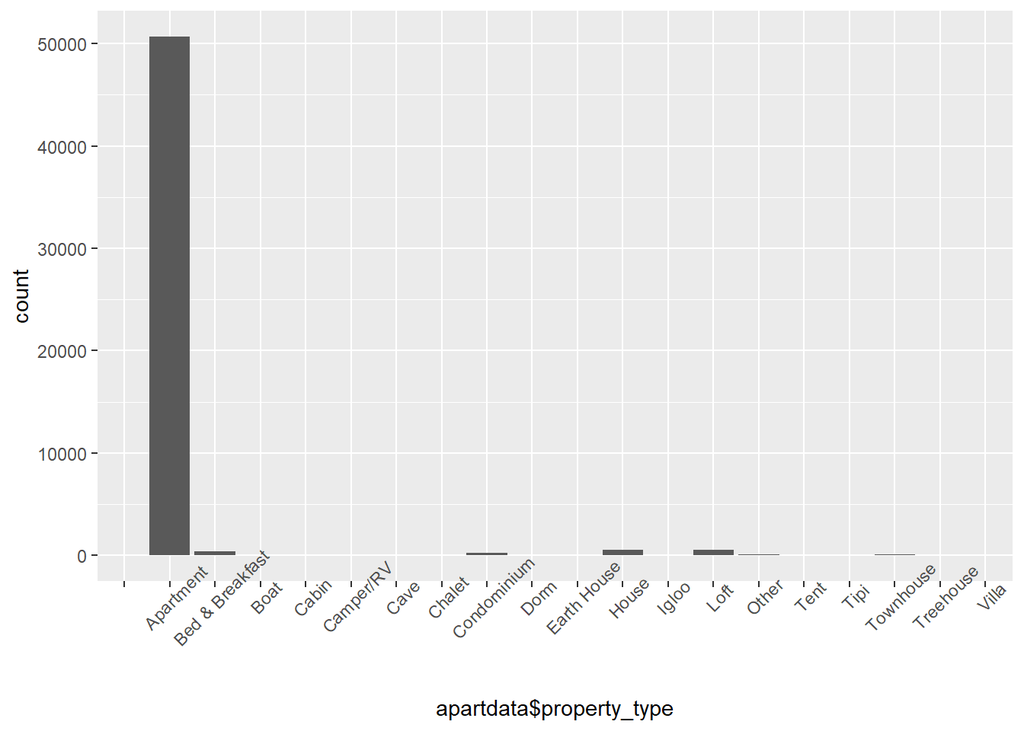

```r
ggplot(data = apartdata) + geom_bar(aes(x=apartdata$property_type))+ theme(axis.text.x = element_text(angle = 45))
```

We can see that the vast majority of the houses are apartments, and although it is clear at a glance, this data is not enough to satisfy my assessment of the price.So I need to use more data for reference.

I wanted to see how many apartments were rented through airbnb in each district and it showed a lot of wrong data by zip code partition, I will work on this later.

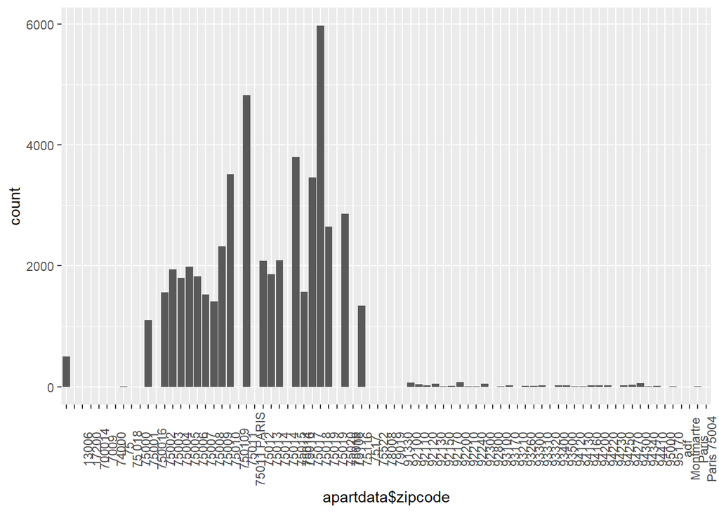

```r
ggplot(data = apartdata) + geom_bar(aes(x=apartdata$zipcode)) + theme(axis.text.x = element_text(angle = 90))
```

I would like to see the connection between the price and the apartment information. First I need to see the missing data.

```r
sum(is.na(apartdata$beds))
```

```
## [1] 80
```

```r
sum(is.na(apartdata$room_type))
```

```
## [1] 0
```

```r
sum(is.na(apartdata$bedrooms))
```

```
## [1] 193
```

```r
sum(is.na(apartdata$bathrooms))
```

```
## [1] 243
```

not much missing value, i cannot calculate a mean value for these type of data so i decided to delete them from database

```r
apartdata <- apartdata %>% drop_na(beds, bedrooms, bathrooms)
```

no missing values

```r
sum(is.na(apartdata$beds))
```

```
## [1] 0
```

```r
sum(is.na(apartdata$room_type))
```

```
## [1] 0
```

```r
sum(is.na(apartdata$bedrooms))
```

```
## [1] 0
```

```r
sum(is.na(apartdata$bathrooms))
```

```
## [1] 0
```

Here i use histogram to show some apartment information

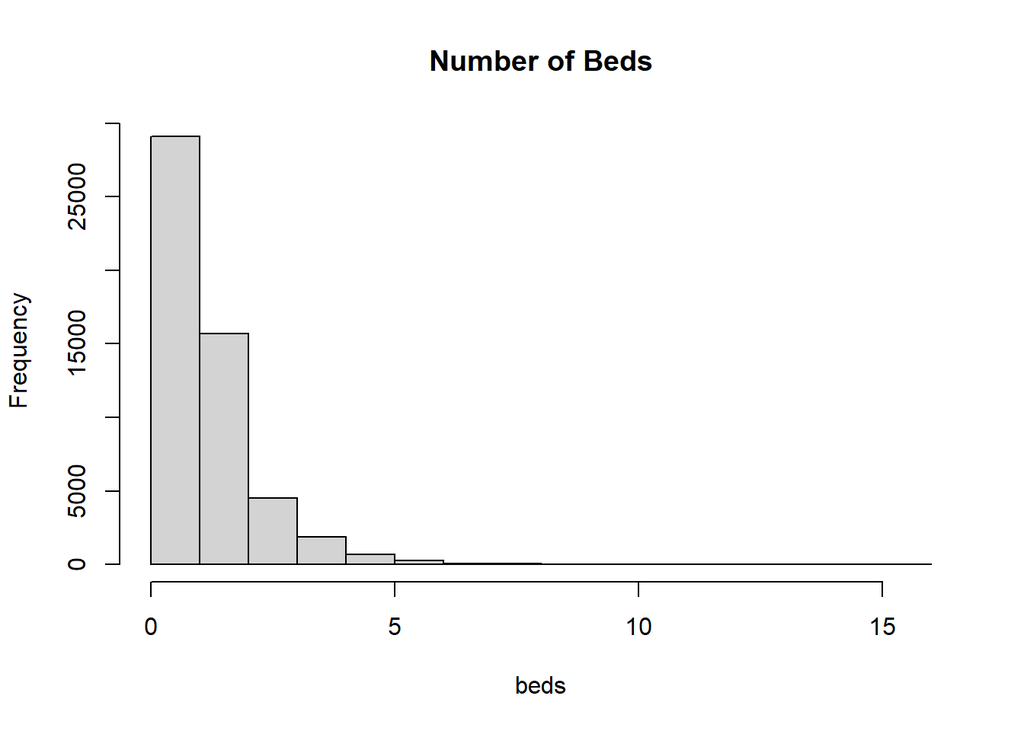

```r
hist(apartdata$beds, main = "Number of Beds", xlab = 'beds')
```

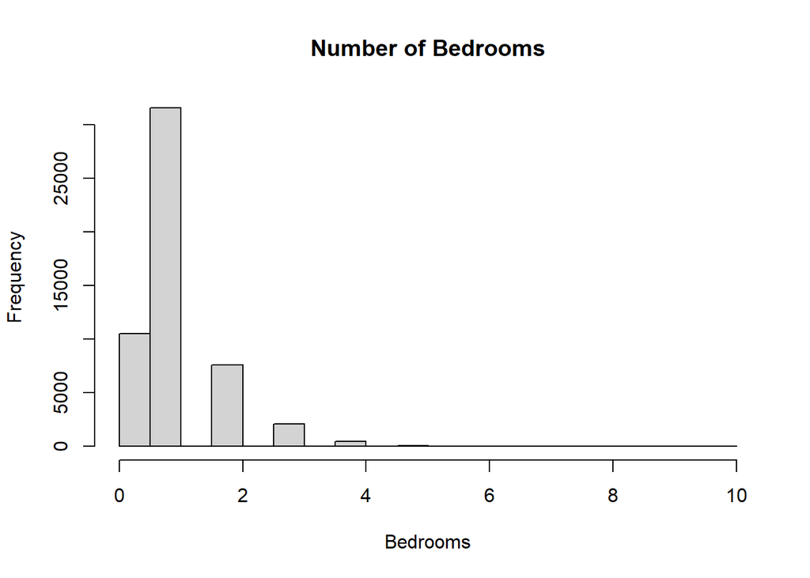

```r
hist(apartdata$bedrooms, main = "Number of Bedrooms", xlab = 'Bedrooms')
```

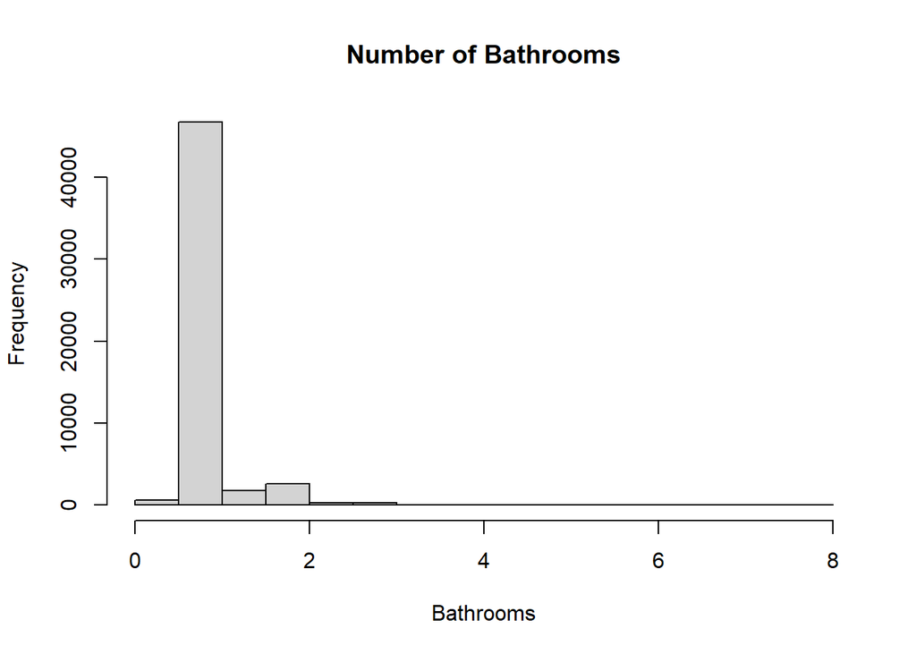

```r
hist(apartdata$bathrooms, main = "Number of Bathrooms", xlab = 'Bathrooms')
```

The number of three types of rooms is shown here

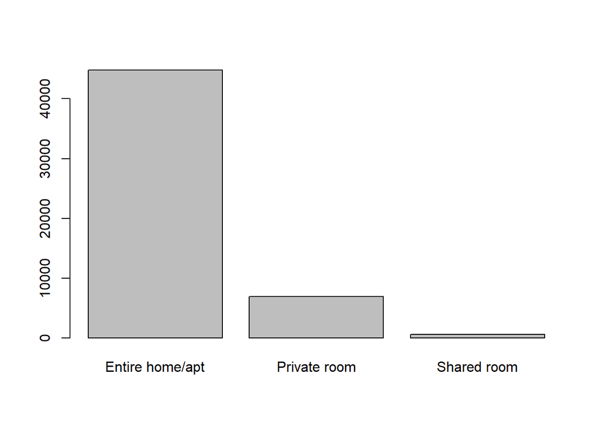

```r
barplot(table(apartdata$room_type))
```

As you can see from this data, most of the apartments for rent are priced at $100 or less.

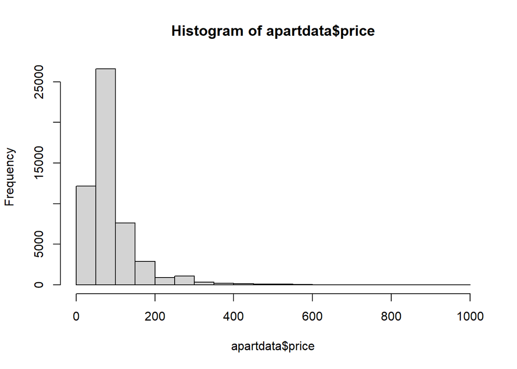

```r
hist(apartdata$price)
```

```r
sum(is.na(mydata$review_scores_rating))
```

```
## [1] 15454
```

```r
sum(is.na(mydata$review_scores_value))
```

```
## [1] 15559
```

```r
sum(is.na(mydata$review_scores_location))
```

```
## [1] 15560
```

```r
sum(is.na(mydata$review_scores_accuracy))
```

```
## [1] 15575
```

Then it occurred to me that the location of the apartment and the neighborhood would also be elements that would affect the price, so I performed the following steps.

```r
levels(apartdata$neighbourhood_cleansed)
```

```
##  [1] "Batignolles-Monceau" "Bourse"              "Buttes-Chaumont"
##  [4] "Buttes-Montmartre"   "Ã‰lysÃ©e"            "EntrepÃ´t"
##  [7] "Gobelins"            "HÃ´tel-de-Ville"     "Louvre"
## [10] "Luxembourg"          "MÃ©nilmontant"       "Observatoire"
## [13] "OpÃ©ra"              "Palais-Bourbon"      "PanthÃ©on"
## [16] "Passy"               "Popincourt"          "Reuilly"
## [19] "Temple"              "Vaugirard"
```

```r
sum(is.na(apartdata$neighbourhood_cleansed))
```

```
## [1] 0
```

```r
table(apartdata$neighbourhood_cleansed)
```

```
##
## Batignolles-Monceau              Bourse     Buttes-Chaumont   Buttes-Montmartre
##                3578                1584                2749                5975
##            Ã‰lysÃ©e           EntrepÃ´t            Gobelins     HÃ´tel-de-Ville
##                1460                3440                1926                1797
##              Louvre          Luxembourg       MÃ©nilmontant        Observatoire
##                1093                1823                2830                2122
##              OpÃ©ra      Palais-Bourbon           PanthÃ©on               Passy
##                2314                1594                1962                3052
##          Popincourt             Reuilly              Temple           Vaugirard
##                4840                2217                2077                3861
```

I tried a little to show a result by the number of beds with the price, but it didn’t work well and I needed to prepare more data, so I left this part for later.

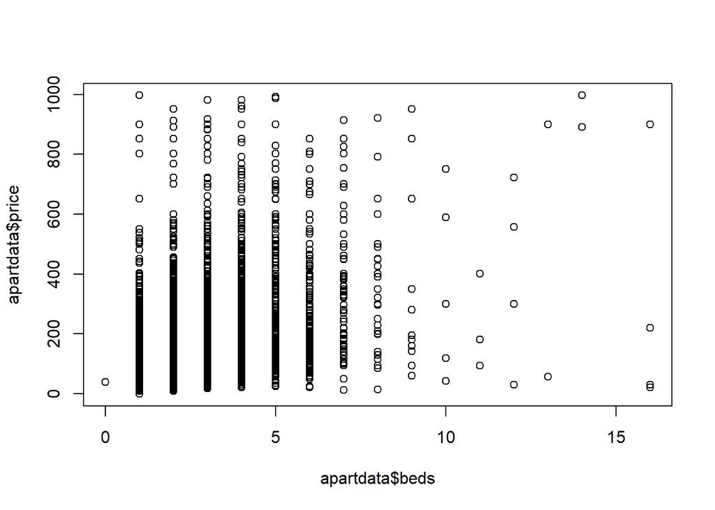

```r
plot(apartdata$beds,apartdata$price)
```

I used the following code to find out the number of apartments held by each owner. Some apartment owners hide personal information or do not collect information about the owner of the apartment.Since they are not missing data, I keep them. The data is more than 9000 rows, it is too crowded to display with graph, so I show the result by the following table:

```r
total_apart = count(apartdata, 'host_name')
head(total_apart, 10)
```

```
##                   host_name freq
## 1                             46
## 2            (EMAIL HIDDEN)   23
## 3  (Url Hidden)HIDDENHIDDEN    1
## 4            (URL HIDDEN)Î‘    3
## 5               1 Rue Affre    1
## 6                 2691lilou    1
## 7                     3pide    1
## 8                         A    3
## 9                        A.    6
## 10                   Aakash    1
```

Now let’s see what data is available in the database for the region

```r
unique(apartdata$zipcode)
```

```
##  [1] 75017        75008        75018                     92200
##  [6] 92300        93400        92110        75013        75116
## [11] 75009        75010        75016        75007        75015
## [16] 75006        75019        75001        75020        75011
## [21] 93310        79019        750109       93260        93300
## [26] 93500        75019\n75019 75004        75002        94230
## [31] 7009         75000        13006        75003        95170
## [36] 75012        75005        94200        74000        75014
## [41] 94250        94270        75           91330        92170
## [46] 92130        94410        94300        94160        94220
## [51] 94120        94130        Paris        78008        700014
## [56] Paris 75004  93100        93170        92100        750016
## [61] 75106        17200        92120        92240        75014\n75014
## [66] 75011 PARIS  75522        93320        7517         75 018
## [71] Montmartre                95000        adf          94340
## [76] 92210        92150        92800        93210
## 79 Levels:    13006 17200 700014 7009 74000 75 75 018 75000 75001 ... Paris 75004
```

```r
sum(is.na(apartdata$zipcode))
```

```
## [1] 0
```

The database contains data with incorrectly filled in area codes and data outside of Paris

```r
zip_data =  count(apartdata, 'zipcode')
head(zip_data, 10)
```

```
##    zipcode freq
## 1           503
## 2             1
## 3    13006    1
## 4    17200    1
## 5   700014    1
## 6     7009    1
## 7    74000    1
## 8       75    5
## 9   75 018    1
## 10   75000    1
```

I chose to use only data from Paris, so I filtered the data from Paris by the following code

```r
paris_data = apartdata[apartdata$zipcode %in% c('75001', '75002', '75003', '75004', '75005', '75006', '75007', '75008'
                                       , '75009', '75010', '75011', '75012', '75013', '75014', '75015', '75016'
                                       , '75017', '75018', '75019', '75020'), ]
```

Then use the count function to calculate how much apartment in each zone

```r
apart_per_quar = count(paris_data, 'zipcode')
apart_per_quar
```

```
##    zipcode freq
## 1    75001 1086
## 2    75002 1548
## 3    75003 1924
## 4    75004 1778
## 5    75005 1972
## 6    75006 1800
## 7    75007 1510
## 8    75008 1403
## 9    75009 2294
## 10   75010 3482
## 11   75011 4786
## 12   75012 2069
## 13   75013 1845
## 14   75014 2079
## 15   75015 3782
## 16   75016 1556
## 17   75017 3442
## 18   75018 5923
## 19   75019 2628
## 20   75020 2836
```

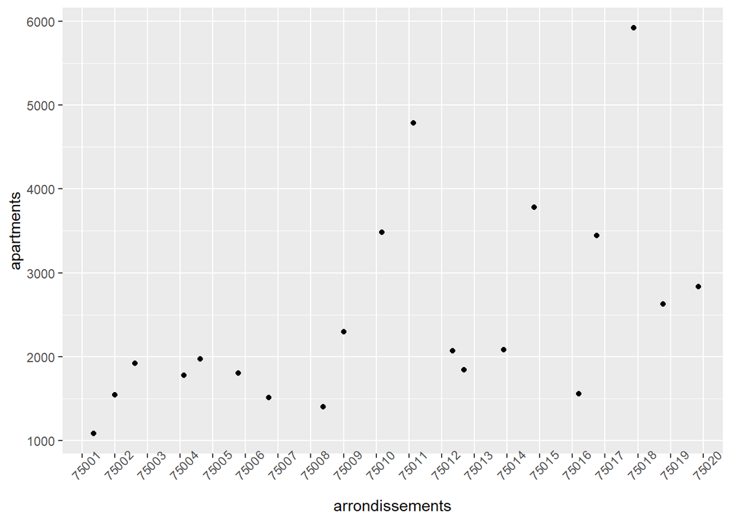

```r
#plot(apart_per_quar$zipcode, apart_per_quar$freq)
ggplot(data = apart_per_quar, aes(x=zipcode, y=freq,)) + geom_jitter()+ xlab('arrondissements') + ylab('apartments') + theme(axis.text.x = element_text(angle = 45))
```

I have used the code below to show the price of renting an apartment in each district of Paris, which is calculated by the number of beds in the apartment

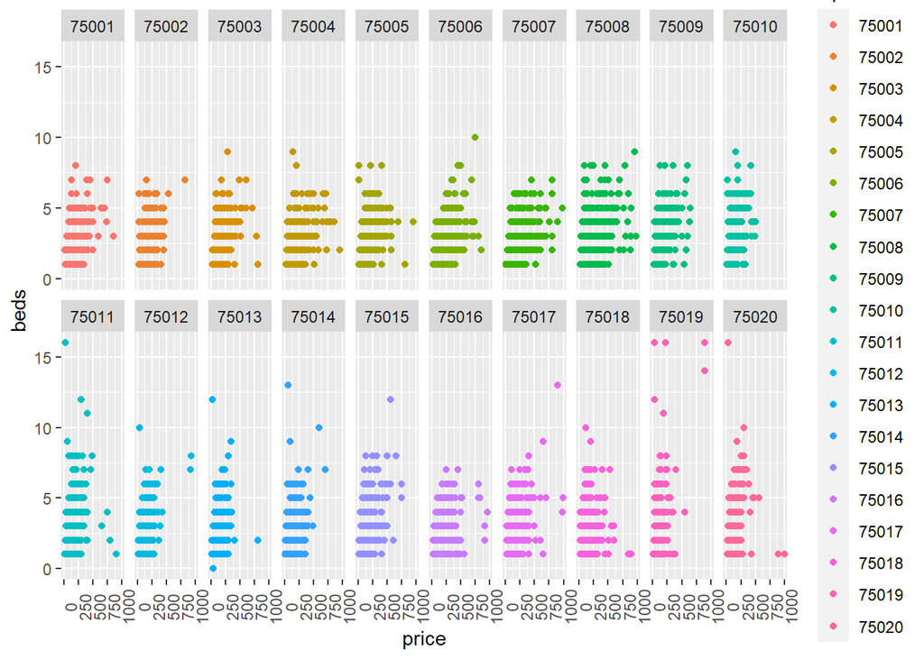

```r
ggplot(data = paris_data) +
  geom_point(aes(x=price , y = beds, col=zipcode)) +
  facet_wrap( ~ zipcode, nrow = 2) + theme(axis.text.x = element_text(angle = 90))
```

The average apartment renting price for each quarter in Paris was then calculated from the data derived above

```r
aggregate(paris_data$price, by=list(paris_data$zipcode), FUN=mean)
```

```
##    Group.1         x
## 1    75001 138.95948
## 2    75002 114.97228
## 3    75003 114.99272
## 4    75004 135.12941
## 5    75005 114.98133
## 6    75006 142.89182
## 7    75007 141.27966
## 8    75008 158.83773
## 9    75009  99.77558
## 10   75010  81.50546
## 11   75011  80.20100
## 12   75012  78.50942
## 13   75013  73.80878
## 14   75014  83.44367
## 15   75015  89.61880
## 16   75016 111.15816
## 17   75017  88.50119
## 18   75018  74.37888
## 19   75019  66.88131
## 20   75020  66.08043
```

Now let’s go to the second table and first check for any missing data

```r
sum(is.na(freq_data$date))
```

```
## [1] 0
```

```r
sum(is.na(freq_data$listing_id))
```

```
## [1] 0
```

Then i count the number of times each apartment is rented. I changed the column names in the new table to make it easier to make connections with other tables

```r
freq_per_quar = count(freq_data, 'listing_id')
names(freq_per_quar)[1] <- 'id'
names(freq_per_quar)[2] <- 'visit_freq'
head(freq_per_quar, 10)
```

```
##      id visit_freq
## 1  2623         66
## 2  4886         13
## 3  4890         11
## 4  5317          2
## 5  5396         82
## 6  6602         91
## 7  7397        141
## 8  8291         27
## 9  9279         14
## 10 9342         36
```

inner join with ‘paris_data’ dataframe

```r
per_time_freq = merge(paris_data, freq_per_quar, by='id')
```

join ‘paris_data’ to ‘freq_data’ (this one is table R in AirBnB.Rdata)

```r
names(freq_data)[1] <- 'id'
new_data = merge(paris_data, freq_data, by='id', all=TRUE)
```

I extracted the “year” from the date and created a new column by following two steps

```r
date_formatted <- as.Date(new_data$date, format = "%Y-%m-%d")
class(date_formatted)
```

```
## [1] "Date"
```

```r
new_data$year <- format(date_formatted, "%Y")
```

Then I calculated the number of apartment rentals per year

```r
year_count = count(new_data, 'year')
year_count
```

```
##   year   freq
## 1 2009     39
## 2 2010    901
## 3 2011   4639
## 4 2012  16566
## 5 2013  47069
## 6 2014 119064
## 7 2015 275755
## 8 2016 199566
## 9 <NA>  13367
```

It can be seen that the number of users renting through airbnb in Paris has been increasing rapidly since 2011, but this trend has been decreasing since 2015

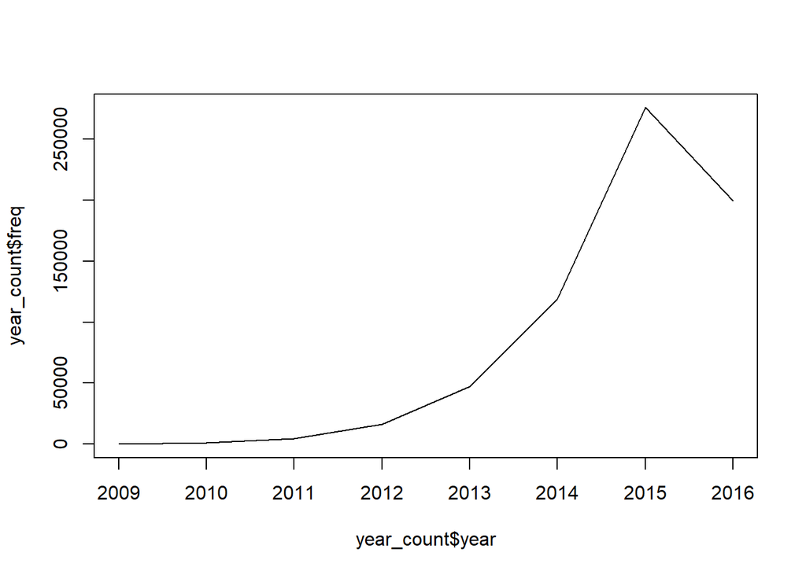

```r
plot(year_count$year, year_count$freq, type = 'l')
```

Visit frequency of the different quarters according to time with graph

```r
quar_count = count(new_data, c("year", "zipcode"))
head(quar_count, 10)
```

```
##    year zipcode freq
## 1  2009   75011    2
## 2  2009   75018    1
## 3  2009   75019    5
## 4  2009    <NA>   31
## 5  2010   75001  104
## 6  2010   75002   19
## 7  2010   75003   48
## 8  2010   75004   52
## 9  2010   75005   47
## 10 2010   75006    3
```

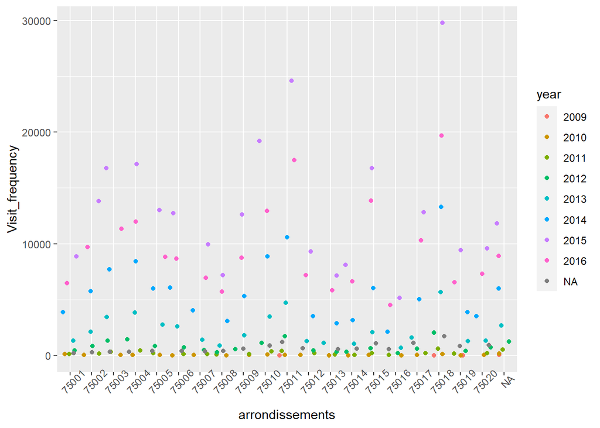

```r
ggplot(quar_count, aes(x = zipcode, y= freq, color = year)) + geom_jitter() + xlab('arrondissements') +
  ylab('Visit_frequency') + theme(axis.text.x = element_text(angle = 45))
```

The map created by leaflet makes it easy to see all the areas of Paris that are available for rent through airbnb

```r
leaflet(data = paris_data) %>%
  addTiles() %>%
  addMarkers(lng = ~longitude,
             lat = ~latitude,
             popup = ~price,
             clusterOptions = markerClusterOptions())
```

[interactive chart not shown]